# Introduction to Differential Gene Expression Analysis with Bulk RNAseq

Gene Set Testing for RNA-seq

September 2023

The list of differentially expressed genes is sometimes so long that its interpretation becomes cumbersome and time consuming. It may also be very short while some genes have low p-value yet higher than the given threshold.

A common downstream procedure to combine information across genes is gene set testing. It aims at finding pathways or gene networks the differentially expressed genes play a role in.

Various ways exist to test for enrichment of biological pathways. We will look into over representation and gene set enrichment analyses.

A gene set comprises genes that share a biological function, chromosomal location, or any other relevant criterion.

To save time and effort there are a number of packages that make applying these tests to a large number of gene sets simpler, and which will import gene lists for testing from various sources.

Today we will use [`clusterProfiler`](https://yulab-smu.github.io/clusterProfiler-book/index.html).

# Over-representation

## Method

This method tests whether genes in a pathway are present in a subset of our data in a higher number than expected by chance (explanations derived from the [clusterProfiler manual](https://yulab-smu.github.io/clusterProfiler-book/index.html)).

Genes in the experiment are split in two ways:

- annotated to the pathway or not
- differentially expressed or not

We can then create a contingency table with:

- rows: genes in pathway or not
- columns: genes differentially expressed or not

And test for independence of the two variables with the Fisher exact test.

## `clusterProfiler`

`clusterprofiler` (Yu et al. 2012) supports direct online access of the current KEGG database (KEGG: Kyoto Encyclopedia of Genes and Genomes), rather than relying on R annotation packages. It also provides some nice visualisation options.

We first search the resource for mouse data:

```r
library(DESeq2)
library(clusterProfiler)
library(tidyverse)

search_kegg_organism('mouse', by='common_name')
```

```
##      kegg_code                            scientific_name
## 20        mmur                         Microcebus murinus
## 22         mmu                               Mus musculus
## 23        mcal                                 Mus caroli
## 24        mpah                                 Mus pahari
## 26        mcoc                            Mastomys coucha
## 29        pleu                        Peromyscus leucopus
## 85        mmyo                              Myotis myotis
## 5095       asf Candidatus Arthromitus sp. SFB-mouse-Japan
## 5096       asm   Candidatus Arthromitus sp. SFB-mouse-Yit
## 5097       aso    Candidatus Arthromitus sp. SFB-mouse-NL
##                                     common_name
## 20                             gray mouse lemur
## 22                                  house mouse
## 23                                 Ryukyu mouse
## 24                                  shrew mouse
## 26                  southern multimammate mouse
## 29                           white-footed mouse
## 85                      greater mouse-eared bat
## 5095 Candidatus Arthromitus sp. SFB-mouse-Japan
## 5096   Candidatus Arthromitus sp. SFB-mouse-Yit
## 5097    Candidatus Arthromitus sp. SFB-mouse-NL
```

We will use the ‘mmu’ ‘kegg_code’.

## KEGG enrichment analysis

The input for the KEGG enrichment analysis is the list of gene IDs of significant genes.

```r
ddsObj.interaction <- readRDS("RObjects/DESeqDataSet.interaction.rds")
results.interaction.11 <- readRDS("RObjects/DESeqResults.interaction_d11.rds")
```

## Shrinking the log2FoldChange

`DESeq2` provides a function called `lfcShrink` that shrinks log-Fold Change (LFC) estimates towards zero using and empirical Bayes procedure. The reason for doing this is that there is high variance in the LFC estimates when counts are low and this results in lowly expressed genes appearing to show greater differences between groups than highly expressed genes. The `lfcShrink` method compensates for this and allows better visualisation and ranking of genes.

```r
ddsShrink.11 <- lfcShrink(ddsObj.interaction,
                       res = results.interaction.11,
                       type = "ashr")
```

```
## using 'ashr' for LFC shrinkage. If used in published research, please cite:
##     Stephens, M. (2016) False discovery rates: a new deal. Biostatistics, 18:2.
##     https://doi.org/10.1093/biostatistics/kxw041
```

```r
shrinkTab.11 <- as.data.frame(ddsShrink.11) %>%
    rownames_to_column("GeneID") %>%
    rename(logFC=log2FoldChange, FDR=padj)
```

## MA plots

MA plots are a common way to visualize the results of a differential analysis. We met them briefly towards the end of the DESeq2 session. This plot shows the log-Fold Change for each gene against its average expression across all samples in the two conditions being contrasted. `DESeq2` has a handy function for plotting this. Let’s use it too compare the shrunk and un-shrunk fold changes.

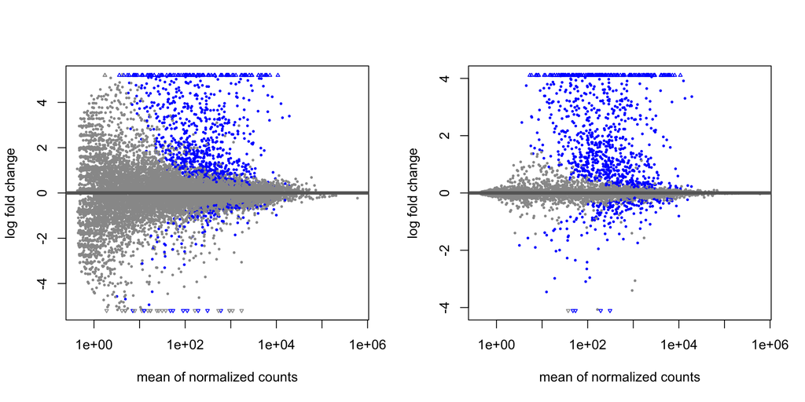

```r
par(mfrow=c(1,2))
plotMA(results.interaction.11, alpha=0.05)
plotMA(ddsShrink.11, alpha=0.05)
```

### Load results with annotion

We now load the R object keeping the outcome of the differential expression analysis for the d11 contrast.

```r
shrink.d11 <- readRDS("RObjects/Shrunk_Results.d11.rds")
```

We will only use genes that have:

- an adjusted p-value (FDR) of less than 0.05
- and an absolute fold change greater than 2.

We need to remember to eliminate genes with missing values in the FDR as a result of the independent filtering by DESeq2.

For this tool we need to use Entrez IDs, so we will also need to eliminate genes with a missing Entrez ID (NA values in the ‘Entrez’ column).

```r
sigGenes <- shrink.d11 %>%
    drop_na(Entrez, FDR) %>%
    filter(FDR < 0.05 & abs(logFC) > 1) %>%
    pull(Entrez)

keggRes <- enrichKEGG(gene = sigGenes, organism = 'mmu')
```

```
## Reading KEGG annotation online: "https://rest.kegg.jp/link/mmu/pathway"...
```

```
## Reading KEGG annotation online: "https://rest.kegg.jp/list/pathway/mmu"...
```

```r
as_tibble(keggRes)
```

```
## # A tibble: 72 × 9
##    ID      Description GeneRatio BgRatio   pvalue p.adjust   qvalue geneID Count
##    <chr>   <chr>       <chr>     <chr>      <dbl>    <dbl>    <dbl> <chr>  <int>
##  1 mmu046… Antigen pr… 40/342    90/9334 4.36e-34 1.03e-31 7.26e-32 14991…    40
##  2 mmu051… Epstein-Ba… 56/342    231/93… 3.77e-31 4.43e-29 3.13e-29 12502…    56
##  3 mmu053… Graft-vers… 32/342    63/9334 8.69e-30 6.81e-28 4.82e-28 14939…    32
##  4 mmu049… Type I dia… 33/342    70/9334 2.61e-29 1.53e-27 1.08e-27 16160…    33
##  5 mmu041… Phagosome … 48/342    182/93… 1.59e-28 7.47e-27 5.29e-27 16414…    48
##  6 mmu053… Allograft … 31/342    63/9334 2.51e-28 9.83e-27 6.95e-27 16160…    31
##  7 mmu051… Influenza … 45/342    173/93… 1.72e-26 5.77e-25 4.09e-25 21706…    45
##  8 mmu045… Cell adhes… 45/342    183/93… 2.28e-25 6.69e-24 4.74e-24 16414…    45
##  9 mmu054… Viral myoc… 32/342    88/9334 4.12e-24 1.08e-22 7.62e-23 16414…    32
## 10 mmu051… Leishmania… 28/342    70/9334 1.43e-22 3.37e-21 2.39e-21 16414…    28
## # ℹ 62 more rows
```

### Visualise a pathway in a browser

`clusterProfiler` has a function `browseKegg` to view the KEGG pathway in a browser, highlighting the genes we selected as differentially expressed.

We will show one of the top hits: pathway ‘mmu04612’ for ‘Antigen processing and presentation’.

```r
browseKEGG(keggRes, 'mmu04612')
```

### Visualise a pathway as a file

The package `pathview` (Luo et al. 2013) can be used to generate figures of KEGG pathways.

One advantage over the `clusterProfiler` browser method `browseKEGG` is that genes can be coloured according to fold change levels in our data. To do this we need to pass `pathview` a named vector of fold change values (one could in fact colour by any numeric vector, e.g. p-value).

The package plots the KEGG pathway to a `png` file in the working directory.

```r
library(pathview)
logFC <- shrink.d11$logFC
names(logFC) <- shrink.d11$Entrez
pathview(gene.data = logFC,
         pathway.id = "mmu04612",
         species = "mmu",
         limit = list(gene=20, cpd=1))
```

*mmu04612.pathview.png*:

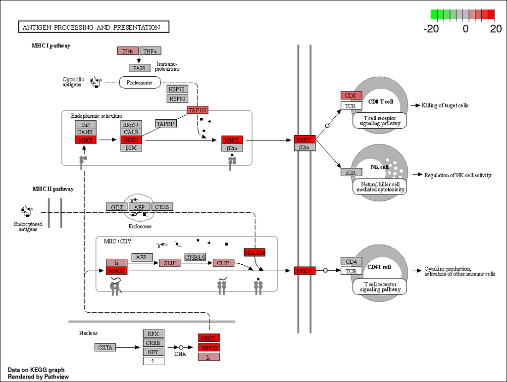

mmu04612 - Antigen processing and presentation

# GO term enrichment analysis

`clusterProfiler` can also perform over-representation analysis on GO terms using the command `enrichGO`. For this analysis we will use Ensembl gene IDs instead of Entrez IDs and in order to do this we need to load another package which contains the mouse database called `org.Mm.eg.db`.

To run the GO enrichment analysis, this time we also need a couple of extra things. Firstly, we should provide a list of the ‘universe’ of all the genes in our DE analysis not just the ones we have selected as significant.

For this analysis we will narrow our search terms in the ‘Biological Processes’ Ontology so we can add the parameter “BP” with the ‘ont’ argument (the default is Molecular Functions).

```r
library(org.Mm.eg.db)

sigGenes_GO <-  shrink.d11 %>%
    drop_na(FDR) %>%
    filter(FDR < 0.01 & abs(logFC) > 2) %>%
    pull(GeneID)

universe <- shrink.d11$GeneID

ego <- enrichGO(gene          = sigGenes_GO,
                universe      = universe,
                OrgDb         = org.Mm.eg.db,
                keyType       = "ENSEMBL",
                ont           = "BP",
                pvalueCutoff  = 0.01,
                readable      = TRUE)
```

We can use the `barplot` function to visualise the results. Count is the number of differentially expressed in each gene ontology term.

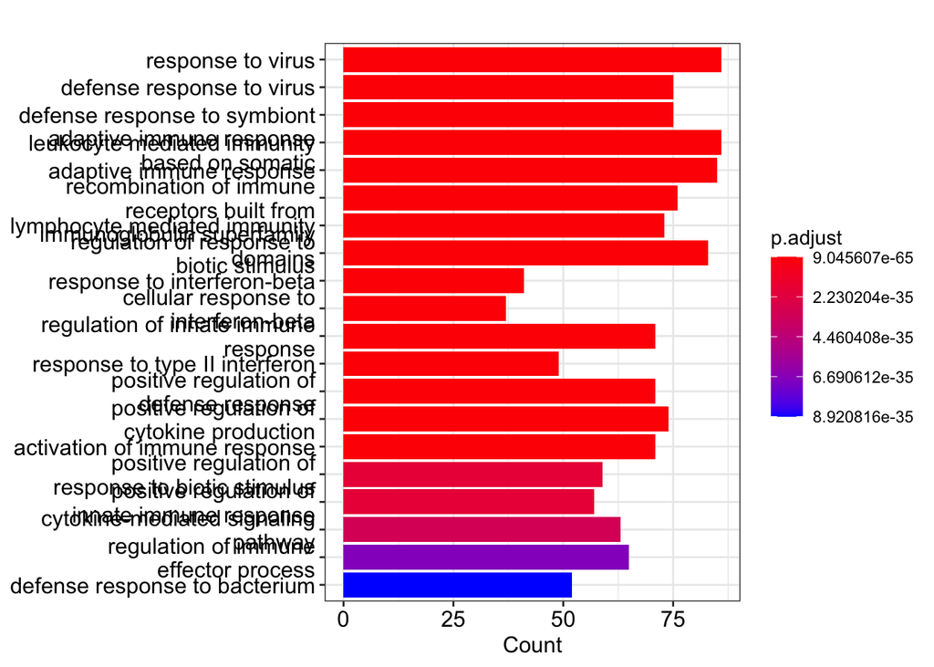

```r
barplot(ego, showCategory=20)
```

or perhaps the `dotplot` version is more informative. Gene ratio is Count divided by the number of genes in that GO term.

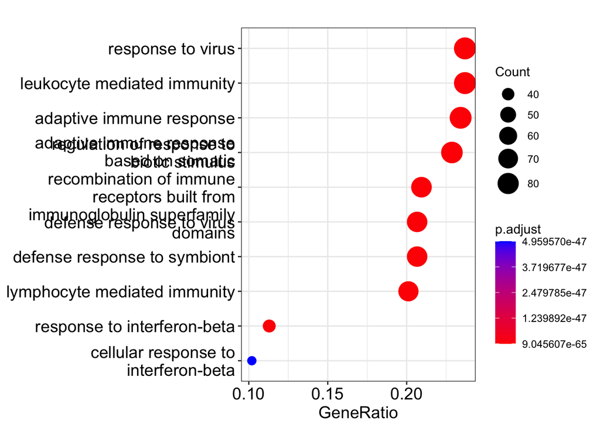

```r
dotplot(ego, font.size = 14)
```

Another visualisation that can be nice to try is the `emapplot` which shows the overlap between genes in the different GO terms.

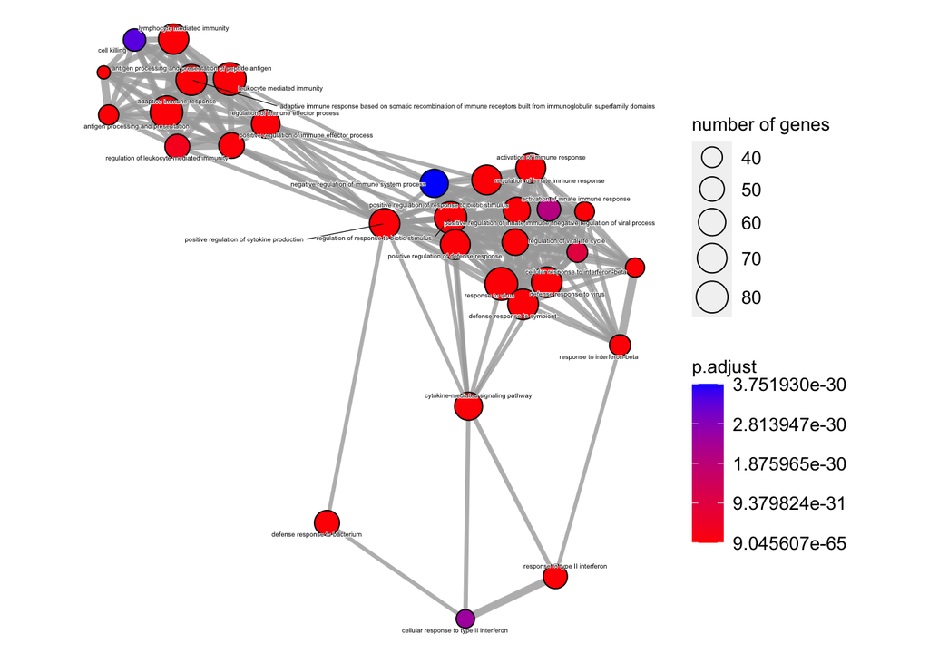

```r
library(enrichplot)
ego_pt <- pairwise_termsim(ego)
emapplot(ego_pt, cex_label_category = 0.25)
```

# GSEA analysis

Gene Set Enrichment Analysis (GSEA) identifies gene sets that are enriched in the dataset between samples (Subramanian et al. 2005).

The software is distributed by the [Broad Institute](http://software.broadinstitute.org/gsea/index.jsp) and is freely available for use by academic and non-profit organisations. The Broad also provide a number of very well curated gene sets for testing against your data - the [Molecular Signatures Database (MSigDB)](http://software.broadinstitute.org/gsea/msigdb/index.jsp). These are collections of human genes. Fortunately, these lists have been translated to mouse equivalents by the Walter+Eliza Hall Institute Bioinformatics service and made available for [download](http://bioinf.wehi.edu.au/MSigDB/index.html). They are now also available from a recent R package [msigdbr](https://cran.r-project.org/web/packages/msigdbr/index.html), which we will use.

Let’s load `msigdbr` now.

```r
library(msigdbr)
```

## Method

The analysis is performed by:

1. ranking all genes in the data set
2. identifying in the ranked data set the rank positions of all members of the gene set
3. calculating an enrichment score (ES) that represents the difference between the observed rankings and that which would be expected assuming a random rank distribution.

The article describing the original software is available [here](http://www.pnas.org/content/102/43/15545.long), while this [commentary on GSEA](https://www.ncbi.nlm.nih.gov/pmc/articles/PMC1266131/) provides a shorter description.

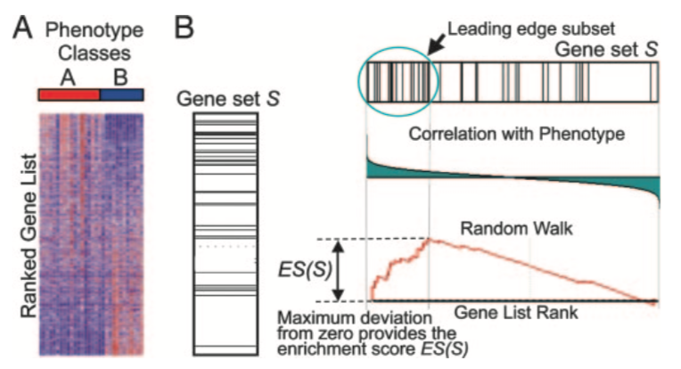

We will use `clusterProfiler`’s [`GSEA`](http://yulab-smu.top/clusterProfiler-book/chapter2.html#gene-set-enrichment-analysis) package (Yu et al. 2012) that implements the same algorithm in R.

## Rank genes

We need to provide `GSEA` with a vector containing values for a given gene mtric, e.g. log(fold change), sorted in decreasing order.

To start with we will simply use a rank the genes based on their fold change.

We must exclude genes with no Ensembl ID.

Also, we should use the shrunk LFC values.

```r
rankedGenes <- shrink.d11 %>%
  filter(!is.na(GeneID)) %>%
  mutate(rank = logFC) %>%
  arrange(desc(rank)) %>%
  pull(rank, GeneID)
```

## Load pathways

We will load the MSigDB Hallmark gene set with `msigdbr`, setting the `category` parameter to ‘H’ for **H**allmark gene set. The object created is a `tibble` with information on each {gene set; gene} pair (one per row). We will only keep the the gene set name, gene Ensembl ID.

```r
term2gene <- msigdbr(species = "Mus musculus", category = "H") %>%
  dplyr::select(gs_name, ensembl_gene)
term2name <- msigdbr(species = "Mus musculus", category = "H") %>%
  dplyr::select(gs_name, gs_description) %>%
  distinct()
```

## Conduct analysis

Arguments passed to `GSEA` include:

- ranked genes
- pathways
- gene set minimum size
- gene set maximum size

```r
gseaRes <- GSEA(rankedGenes,
                TERM2GENE = term2gene,
                TERM2NAME = term2name,
                pvalueCutoff = 1.00,
                minGSSize = 15,
                maxGSSize = 500)
```

```
## preparing geneSet collections...
```

```
## GSEA analysis...
```

```
## leading edge analysis...
```

```
## done...
```

Let’s look at the top 10 results.

```r
as_tibble(gseaRes) %>%
  arrange(desc(abs(NES))) %>%
  top_n(10, wt=-p.adjust) %>%
  dplyr::select(-core_enrichment) %>%
  mutate(across(c("enrichmentScore", "NES"), round, digits=3)) %>%
  mutate(across(c("pvalue", "p.adjust", "qvalue"), scales::scientific))
```

|  | ID | Description | setSize | enrichmentScore | NES | pvalue | p.adjust | qvalue | rank | leading_edge |
| --- | --- | --- | --- | --- | --- | --- | --- | --- | --- | --- |
| 1 | HALLMARK_INTERFERON_ALPHA_RESPONSE | Genes up-regulated in response to alpha interferon proteins. | 97 | 0.957 | 1.428 | 1.00e-10 | 1.67e-09 | 1.33e-09 | 767 | tags=79%, list=4%, signal=77% |
| 2 | HALLMARK_INTERFERON_GAMMA_RESPONSE | Genes up-regulated in response to IFNG [GeneID=3458]. | 203 | 0.951 | 1.42 | 1.00e-10 | 1.67e-09 | 1.33e-09 | 894 | tags=70%, list=4%, signal=68% |
| 3 | HALLMARK_IL6_JAK_STAT3_SIGNALING | Genes up-regulated by IL6 [GeneID=3569] via STAT3 [GeneID=6774], e.g., during acute phase response. | 84 | 0.93 | 1.382 | 6.31e-06 | 5.26e-05 | 4.21e-05 | 1095 | tags=50%, list=5%, signal=47% |
| 4 | HALLMARK_ALLOGRAFT_REJECTION | Genes up-regulated during transplant rejection. | 197 | 0.923 | 1.379 | 1.00e-10 | 1.67e-09 | 1.33e-09 | 915 | tags=47%, list=5%, signal=45% |
| 5 | HALLMARK_INFLAMMATORY_RESPONSE | Genes defining inflammatory response. | 196 | 0.905 | 1.351 | 1.13e-08 | 1.42e-07 | 1.13e-07 | 1087 | tags=39%, list=5%, signal=38% |
| 6 | HALLMARK_TNFA_SIGNALING_VIA_NFKB | Genes regulated by NF-kB in response to TNF [GeneID=7124]. | 196 | 0.898 | 1.34 | 1.04e-07 | 1.04e-06 | 8.33e-07 | 1167 | tags=35%, list=6%, signal=33% |
| 7 | HALLMARK_APOPTOSIS | Genes mediating programmed cell death (apoptosis) by activation of caspases. | 158 | 0.887 | 1.326 | 1.73e-05 | 9.64e-05 | 7.71e-05 | 1125 | tags=23%, list=6%, signal=22% |
| 8 | HALLMARK_COMPLEMENT | Genes encoding components of the complement system, which is part of the innate immune system. | 189 | 0.882 | 1.313 | 9.91e-06 | 7.08e-05 | 5.66e-05 | 1134 | tags=30%, list=6%, signal=28% |
| 9 | HALLMARK_IL2_STAT5_SIGNALING | Genes up-regulated by STAT5 in response to IL2 stimulation. | 195 | 0.877 | 1.309 | 1.47e-05 | 9.16e-05 | 7.33e-05 | 923 | tags=21%, list=5%, signal=20% |
| 10 | HALLMARK_COAGULATION | Genes encoding components of blood coagulation system; also up-regulated in platelets. | 129 | 0.858 | 1.281 | 5.52e-03 | 2.76e-02 | 2.21e-02 | 1108 | tags=20%, list=6%, signal=19% |

## Enrichment score plot

The enrichment score plot displays along the x-axis that represents the decreasing gene rank:

- genes involved in the pathway under scrutiny: one black tick per gene in the pathway (no tick for genes not in the pathway)
- the enrichment score: the green curve shows the difference between the observed rankings and that which would be expected assuming a random rank distribution.

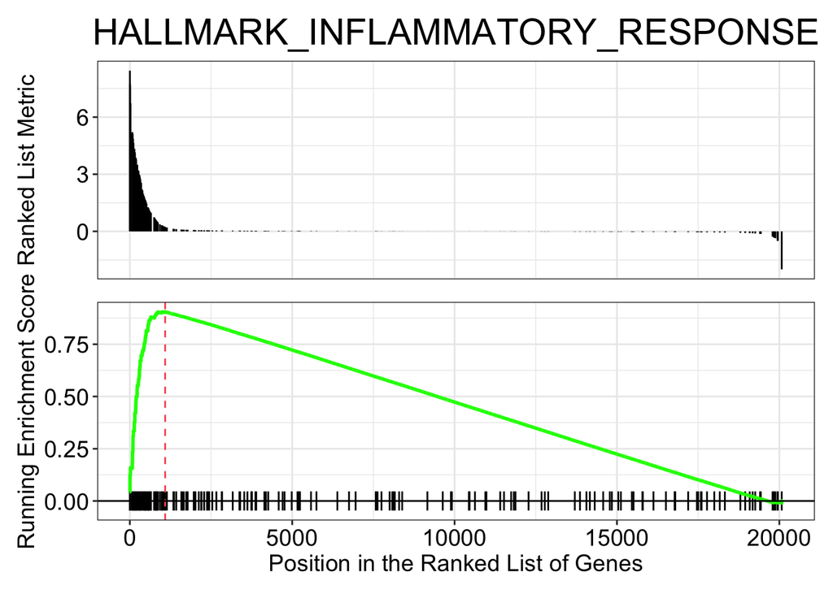

```r
gseaplot(gseaRes,
         geneSetID = "HALLMARK_INFLAMMATORY_RESPONSE",
         title = "HALLMARK_INFLAMMATORY_RESPONSE")
```

Remember to check the [GSEA article](http://www.pnas.org/content/102/43/15545.full) for the complete explanation.

# References

Luo, Weijun, Brouwer, and Cory. 2013. “Pathview: An r/Bioconductor Package for Pathway-Based Data Integration and Visualization.” *Bioinformatics* 29 (14): 1830–31. https://doi.org/10.1093/bioinformatics/btt285.

Subramanian, Aravind, Pablo Tamayo, Vamsi K. Mootha, Sayan Mukherjee, Benjamin L. Ebert, Michael A. Gillette, Amanda Paulovich, et al. 2005. “Gene Set Enrichment Analysis: A Knowledge-Based Approach for Interpreting Genome-Wide Expression Profiles.” *Proceedings of the National Academy of Sciences* 102 (43): 15545–50. https://doi.org/10.1073/pnas.0506580102.

Yu, Guangchuang, Li-Gen Wang, Yanyan Han, and Qing-Yu He. 2012. “clusterProfiler: An r Package for Comparing Biological Themes Among Gene Clusters.” *OMICS: A Journal of Integrative Biology* 16 (5): 284–87. https://doi.org/10.1089/omi.2011.0118.